# Red Wine Quality Analysis by Abhirath Kumar

# Univariate Plots Section

```
## [1] 1599   13
```

```
## 'data.frame':    1599 obs. of  13 variables:
##  $ X                   : int  1 2 3 4 5 6 7 8 9 10 ...
##  $ fixed.acidity       : num  7.4 7.8 7.8 11.2 7.4 7.4 7.9 7.3 7.8 7.5 ...
##  $ volatile.acidity    : num  0.7 0.88 0.76 0.28 0.7 0.66 0.6 0.65 0.58 0.5 ...
##  $ citric.acid         : num  0 0 0.04 0.56 0 0 0.06 0 0.02 0.36 ...
##  $ residual.sugar      : num  1.9 2.6 2.3 1.9 1.9 1.8 1.6 1.2 2 6.1 ...
##  $ chlorides           : num  0.076 0.098 0.092 0.075 0.076 0.075 0.069 0.065 0.073 0.071 ...
##  $ free.sulfur.dioxide : num  11 25 15 17 11 13 15 15 9 17 ...
##  $ total.sulfur.dioxide: num  34 67 54 60 34 40 59 21 18 102 ...
##  $ density             : num  0.998 0.997 0.997 0.998 0.998 ...
##  $ pH                  : num  3.51 3.2 3.26 3.16 3.51 3.51 3.3 3.39 3.36 3.35 ...
##  $ sulphates           : num  0.56 0.68 0.65 0.58 0.56 0.56 0.46 0.47 0.57 0.8 ...
##  $ alcohol             : num  9.4 9.8 9.8 9.8 9.4 9.4 9.4 10 9.5 10.5 ...
##  $ quality             : Factor w/ 6 levels "3","4","5","6",..: 3 3 3 4 3 3 3 5 5 3 ...
```

```
##        X          fixed.acidity   volatile.acidity  citric.acid
##  Min.   :   1.0   Min.   : 4.60   Min.   :0.1200   Min.   :0.000
##  1st Qu.: 400.5   1st Qu.: 7.10   1st Qu.:0.3900   1st Qu.:0.090
##  Median : 800.0   Median : 7.90   Median :0.5200   Median :0.260
##  Mean   : 800.0   Mean   : 8.32   Mean   :0.5278   Mean   :0.271
##  3rd Qu.:1199.5   3rd Qu.: 9.20   3rd Qu.:0.6400   3rd Qu.:0.420
##  Max.   :1599.0   Max.   :15.90   Max.   :1.5800   Max.   :1.000
##  residual.sugar     chlorides       free.sulfur.dioxide
##  Min.   : 0.900   Min.   :0.01200   Min.   : 1.00
##  1st Qu.: 1.900   1st Qu.:0.07000   1st Qu.: 7.00
##  Median : 2.200   Median :0.07900   Median :14.00
##  Mean   : 2.539   Mean   :0.08747   Mean   :15.87
##  3rd Qu.: 2.600   3rd Qu.:0.09000   3rd Qu.:21.00
##  Max.   :15.500   Max.   :0.61100   Max.   :72.00
##  total.sulfur.dioxide    density             pH          sulphates
##  Min.   :  6.00       Min.   :0.9901   Min.   :2.740   Min.   :0.3300
##  1st Qu.: 22.00       1st Qu.:0.9956   1st Qu.:3.210   1st Qu.:0.5500
##  Median : 38.00       Median :0.9968   Median :3.310   Median :0.6200
##  Mean   : 46.47       Mean   :0.9967   Mean   :3.311   Mean   :0.6581
##  3rd Qu.: 62.00       3rd Qu.:0.9978   3rd Qu.:3.400   3rd Qu.:0.7300
##  Max.   :289.00       Max.   :1.0037   Max.   :4.010   Max.   :2.0000
##     alcohol      quality
##  Min.   : 8.40   3: 10
##  1st Qu.: 9.50   4: 53
##  Median :10.20   5:681
##  Mean   :10.42   6:638
##  3rd Qu.:11.10   7:199
##  Max.   :14.90   8: 18
```

There are 1599 wines in this dataset. Most wines seem to have a quality rating of 5 or 6 and the range of ratings are from 3-8 implying that no wine expert rated any of the wines on the extreme ends of the scales. ie. very low(0,1,2) and very high(9,10).

75% of wines have a pH rating below 3.4 which implies that most wines are atleast moderately acidic.

75% of wines have 21mg or lower concentrations of free sulfur dioxide in them.

The median density of the wines is 0.9968 which is very close to the density of water

The mean alcohol content in the wines of the dataset is 10.42%

Since the guiding question for this analysis is ‘Which chemical properties influence the quality of red wines?’, I wanted to look at the distribution of quality first.

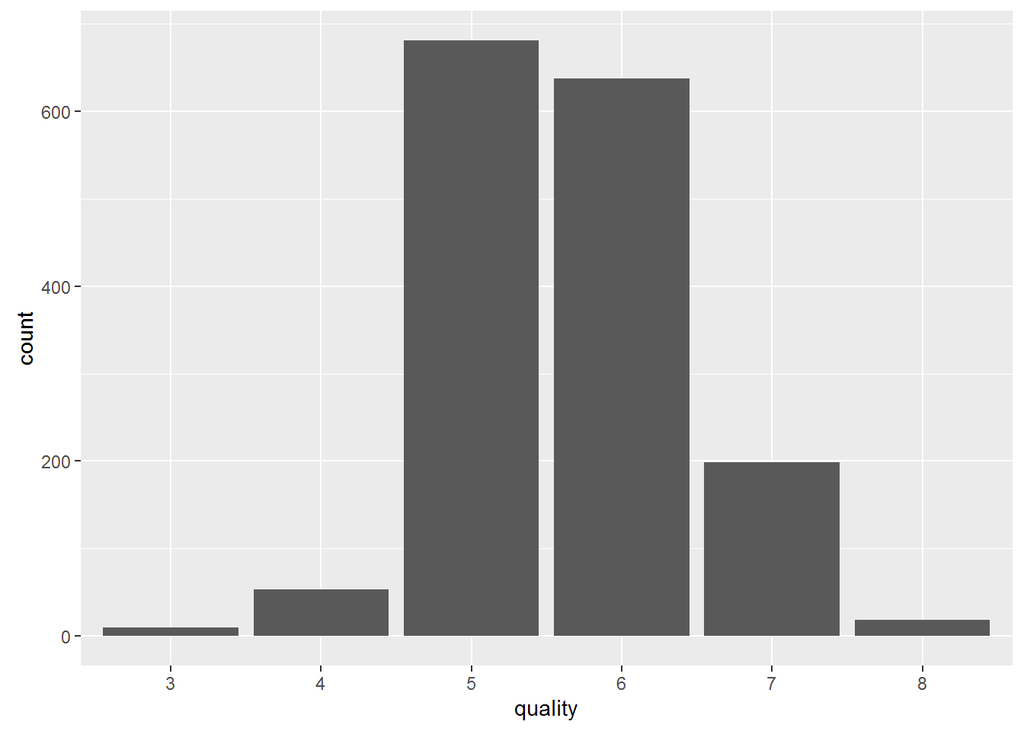

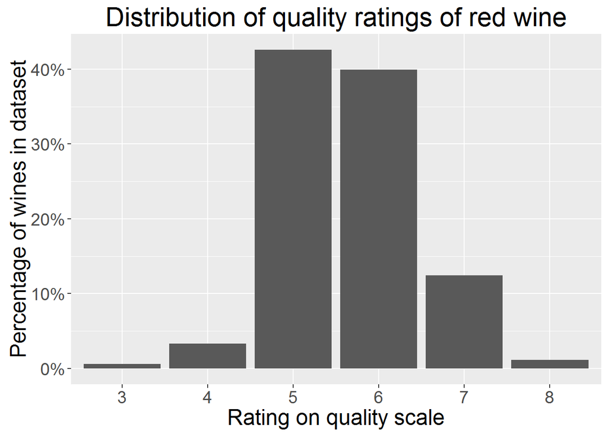

Here we can see that a large percentage of the wines were ranked as a 5 or a 6 (over 80% to be more precise). The distribution of the quality ratings of the wines seems to be somewhat normal.

Next I thought it would be worthwhile to look at the distributions of all the variables to learn more about the distribution of the data.

## Fixed Acidity

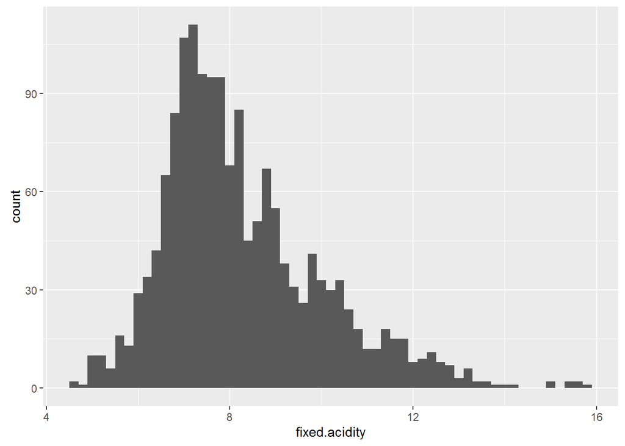

Generally most wines seem to have a fixed acidity level between 7-8 but the range of values extends from around 4 till 16 g/dm3

## Volatile Acidity

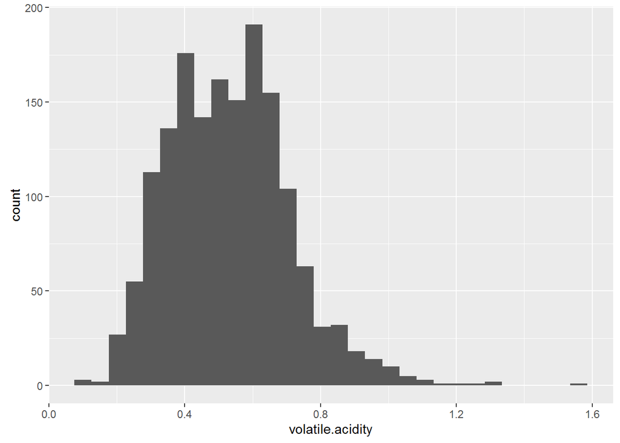

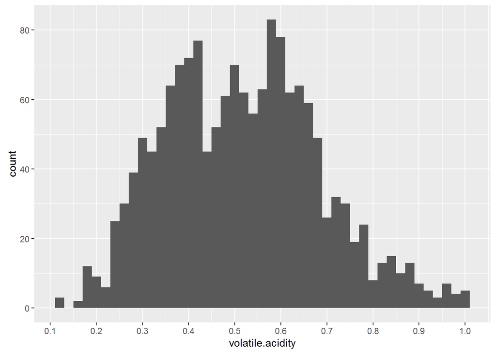

After removing outliers above around 1 (the exact value was determined with the IQR and 75th percentile), we see that the distribution of volatile acidity looks bi modal with 2 peaks around 0.4 and 0.6

## Citric Acid

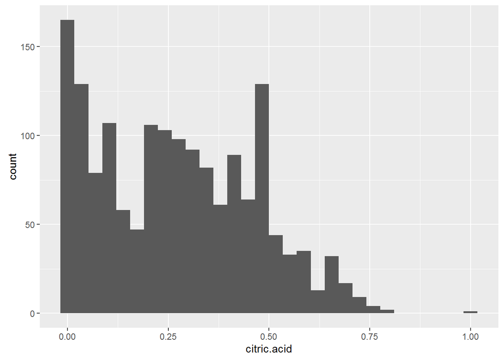

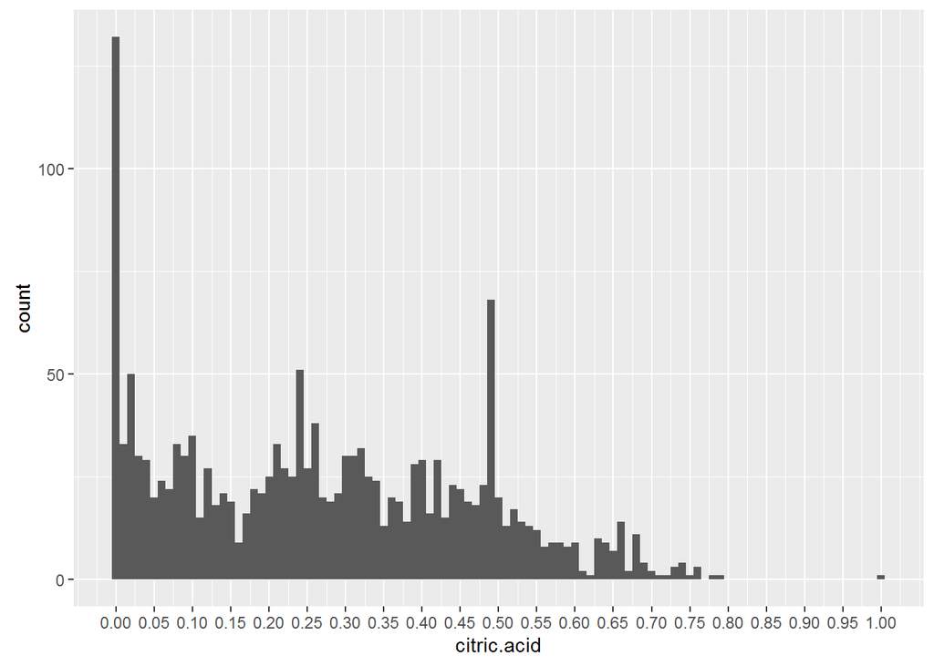

For citric acid content, there seems to be a peaks around 0 and 0.49 g/dm3 but there is also a clear outlier at 1g/dm3. Apart from that most of the values lie between 0 and 0.75

## Residual Sugar

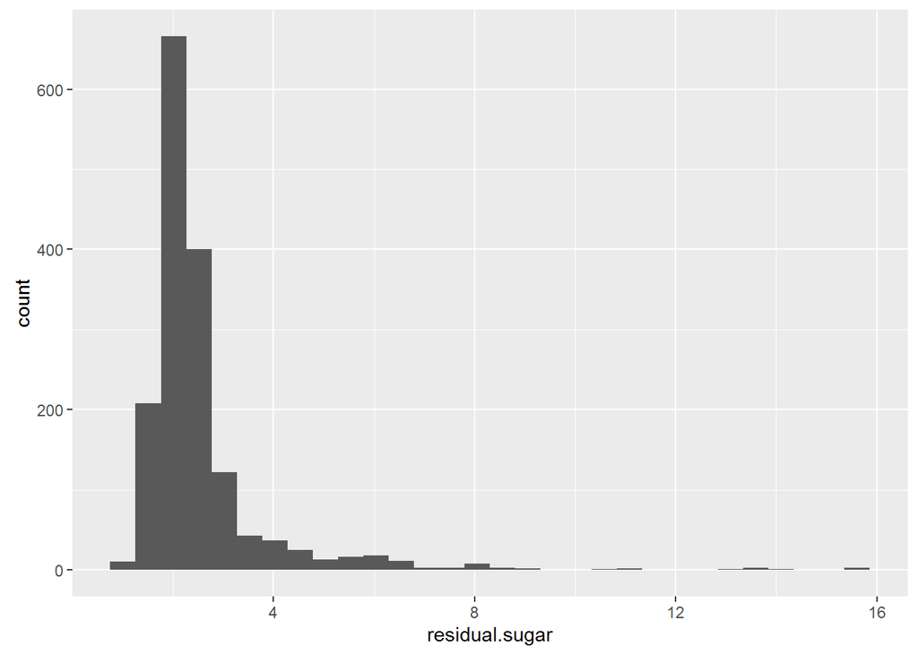

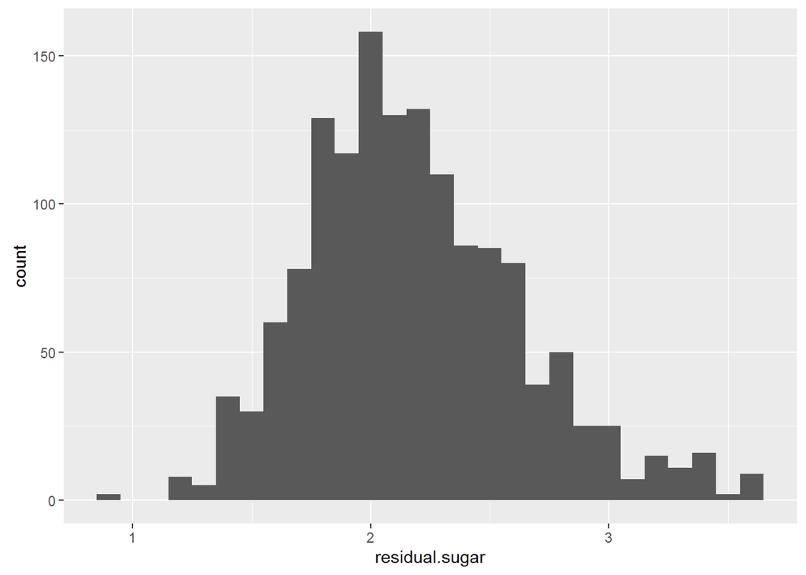

After removing outliers, the distribution of residual sugars in the wines of the dataset looks normally distributed

## Chlorides

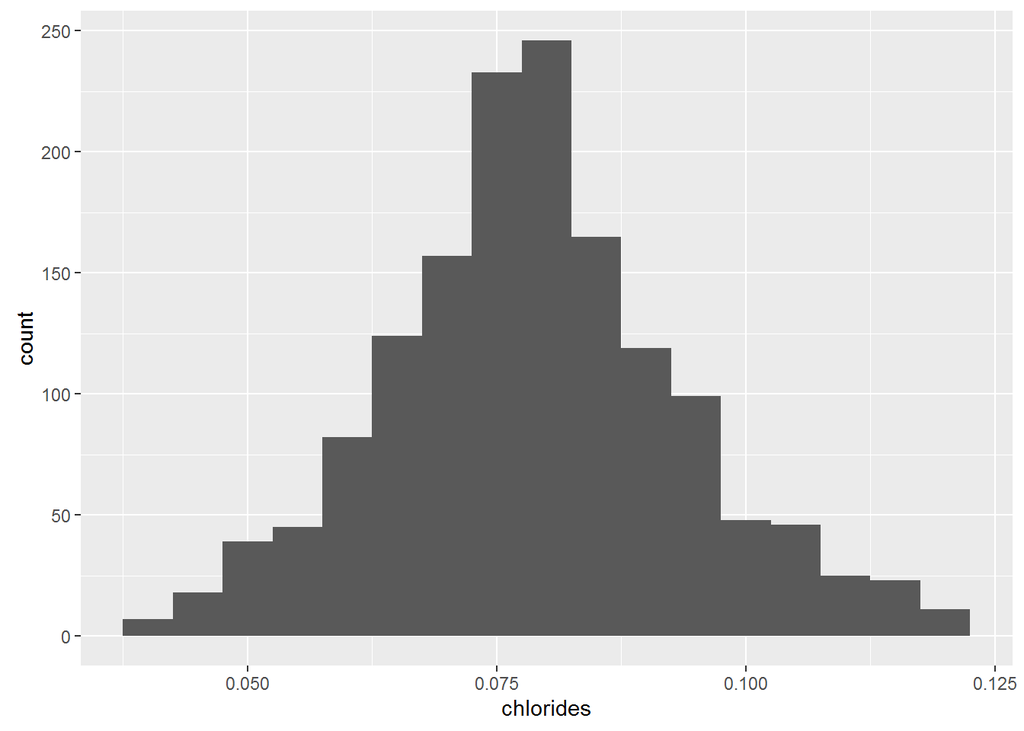

Once again, after removing outliers, the distribution of cholorides in the wine looks like it is normally distributed

## Free Sulfur Dioxide

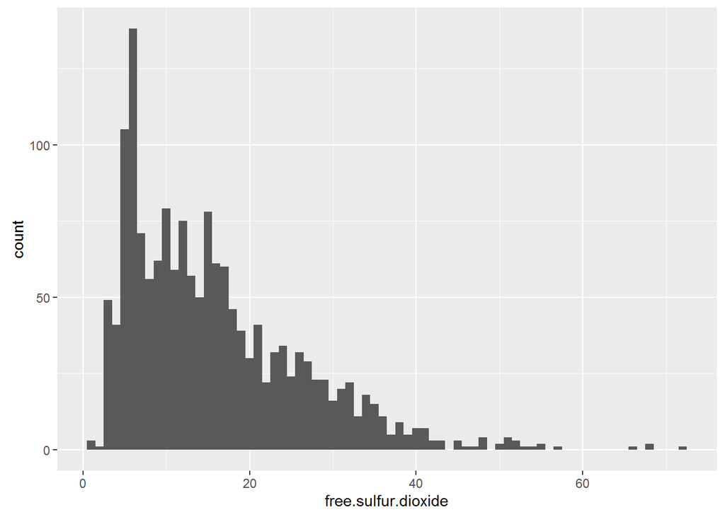

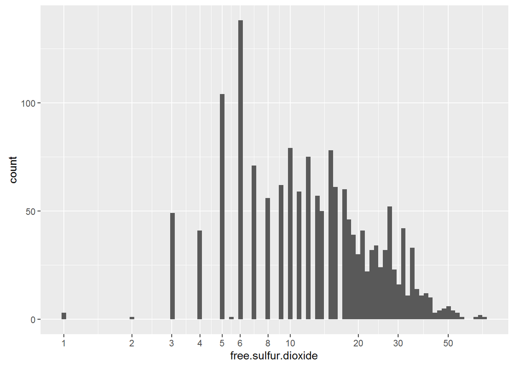

After transforming the distribution to log scale (given its long tail nature), it looks like there is a peak at 6 g/dm3 and that most of the sulfur dioxide values are whole numbers

## Total Sulfur Dioxide

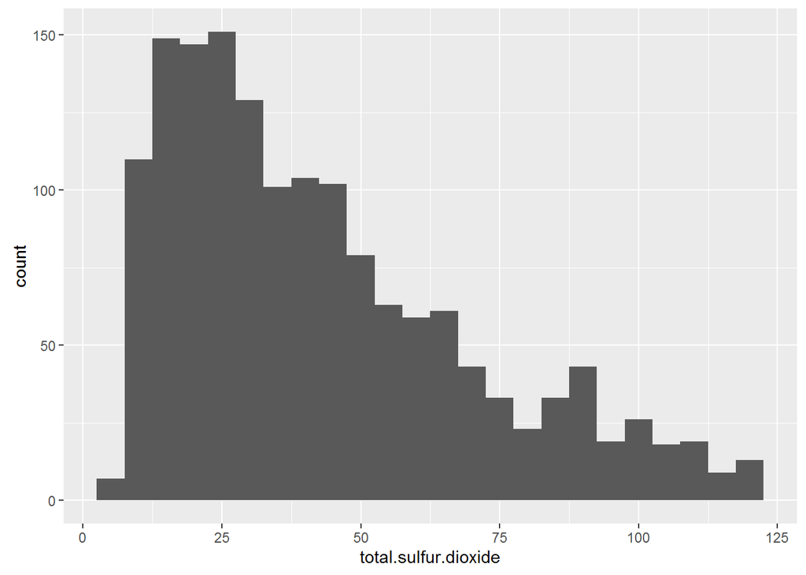

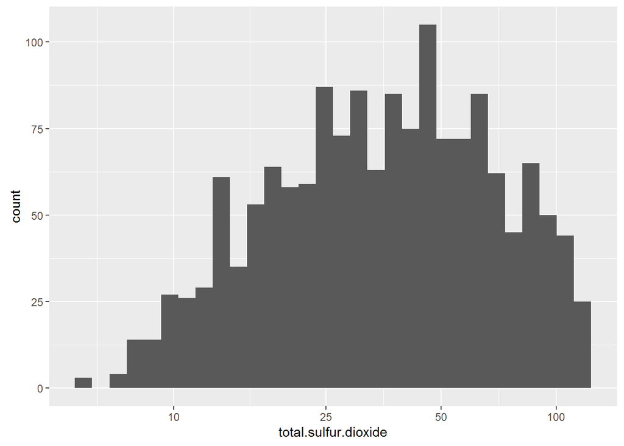

After removing outliers and transforming the distribution (due to the long tail nature) we can see that the distribution has a slight peak at around 50.

## Density

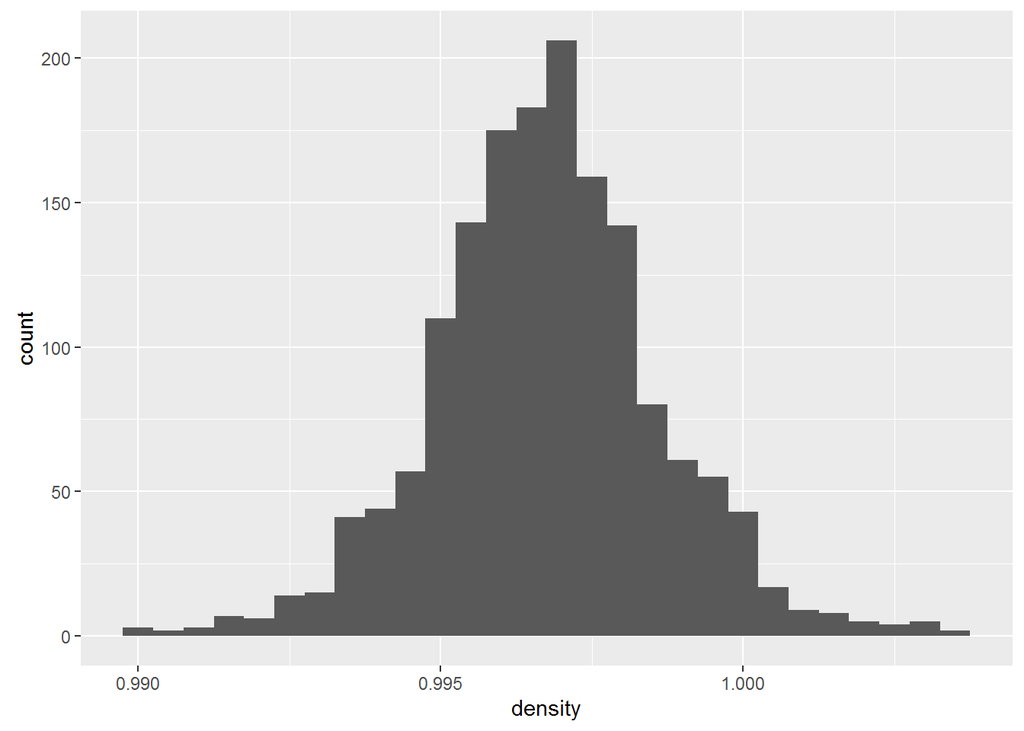

We can see from the visualisation above that the density of the wines is normally distributed and that the peak of the denisity distribution is just less than the density of water (which is around 1). Most wines are not as dense as water but there are a few in the dataset that seem to be an exception

## pH

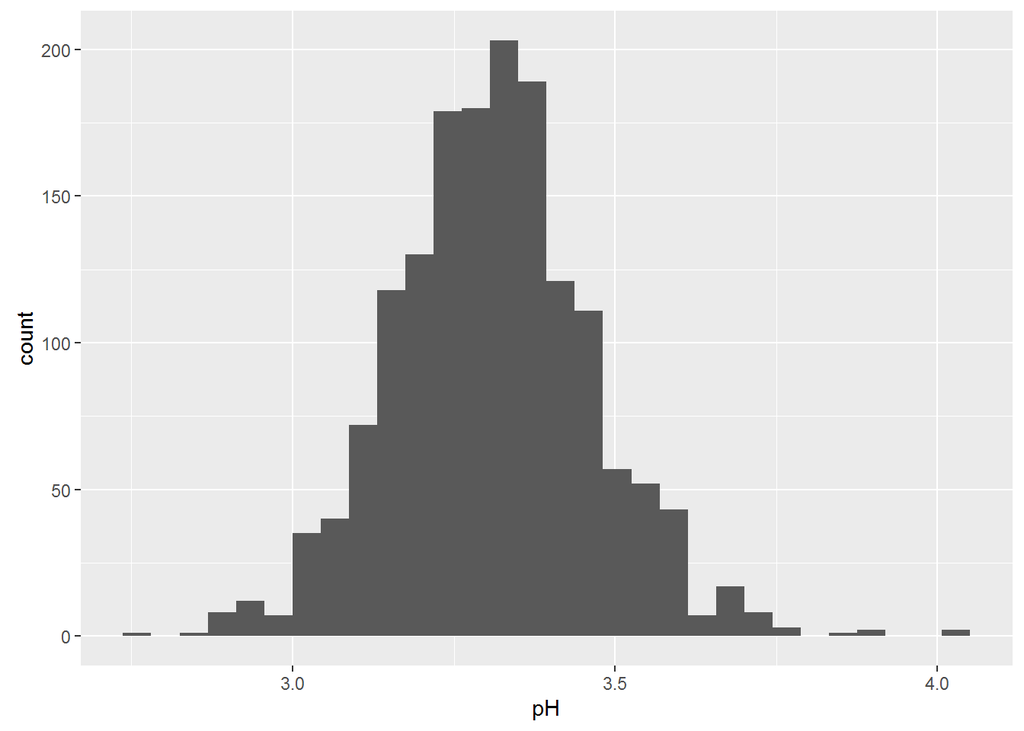

The pH of the wines is always acidic. The distribution of the pH values is normal

## Sulphates

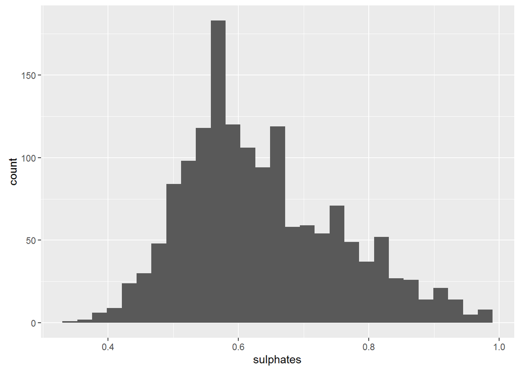

After removing outliers we can see that the distribution of sulphates peaks just before 0.6. The distribution also looks slightly skewed towards the right.

## Alcohol

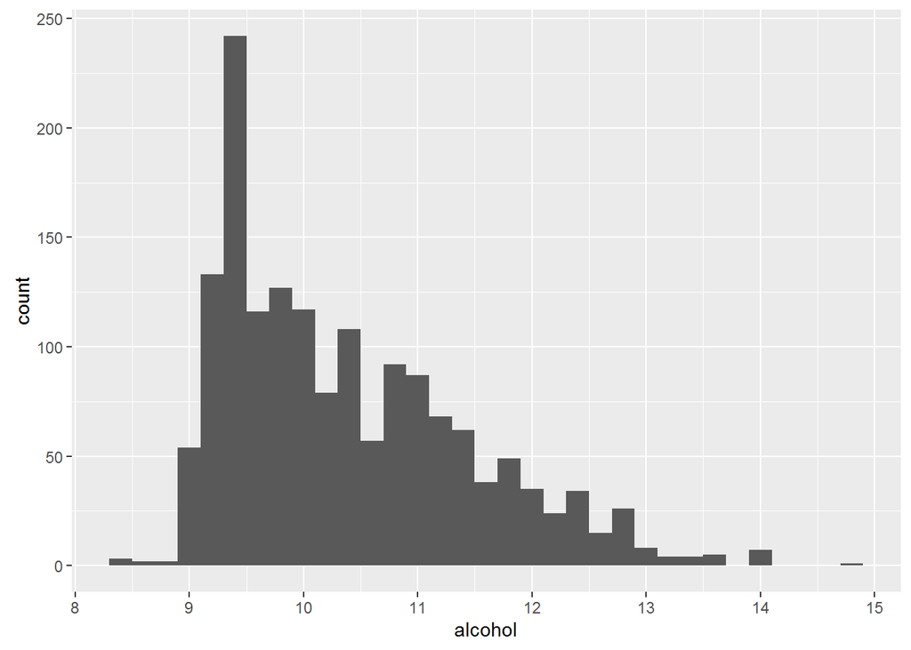

Most wines in the dataset seem to have an alcohol content of between 9% and 13% with the median value at 10.2% and a clear peak around 9.5%

# Univariate Analysis

### What is the structure of your dataset?

The dataset I’ve chosen to examine is the red wine dataset. This dataset has 1599 wines with 13 features describing each of the wines (1599 x 13)

### What is/are the main feature(s) of interest in your dataset?

Based on the guiding question for this dataset, I beleive that the main feature of interest is the quality of the wine.

### What other features in the dataset do you think will help support your investigation into your feature(s) of interest?

The guiding question is to find out what chemical properties (which are features in this dataset) affect the quality of wine. At this point I think many of the features (chemical properties) could have an influence on the quality of the wine but I would refrain from answering concretely till I have conducted a bivariate analysis. At this point though, I imagine that all of the chemical properties would affect the quality of the wine in some way

### Did you create any new variables from existing variables in the dataset?

No I did not

### Of the features you investigated, were there any unusual distributions? Did you perform any operations on the data to tidy, adjust, or change the form of the data? If so, why did you do this?

The distributions of free and total sulfur dioxide were skewed to the right and I performed log transformations on them to get a better idea of the underlying distribution.

In the case of sulphates, chlorides, total sulfur dioxide, residual sugar and volatile acidity, I removed outliers while plotting their distributions as I felt that the resultant graph was better representative of the feature’s underlying distribution.

# Bivariate Plots Section

To start off my bivariate distribution I thought it would be a good idea to to use the corrplot package and its function to give me a correaltion matrix. I thought that this would give me a good idea on what relationships my analysis should look at next.

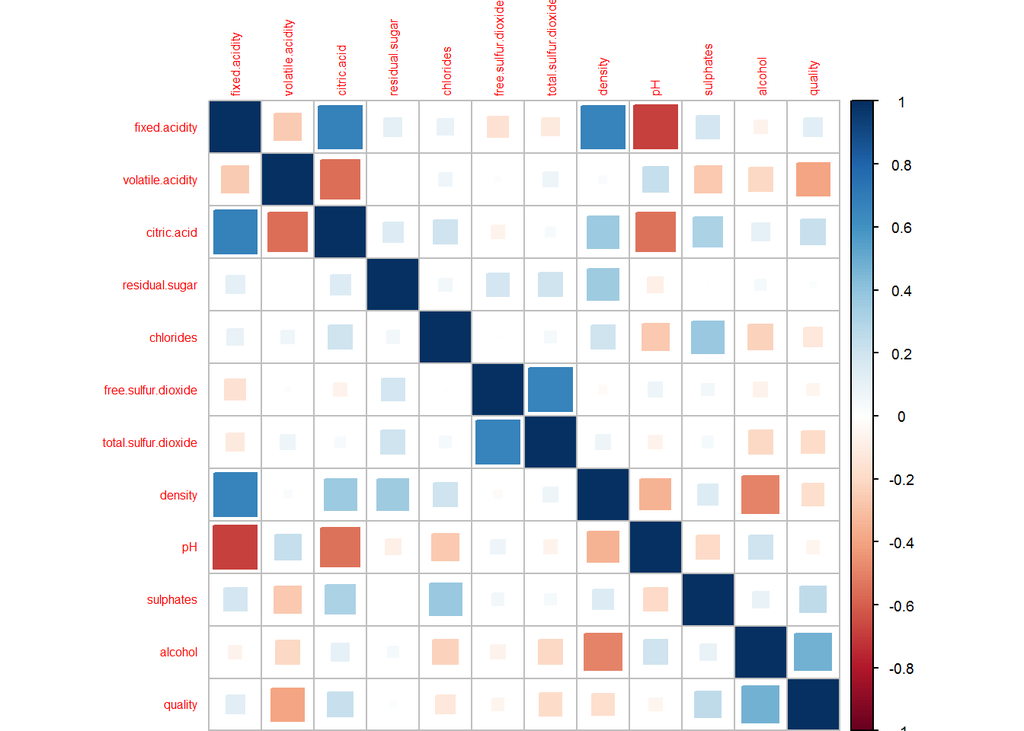

Looking at the correlations, I decided that at this point it would be interesting to examine, in more detail, the relationships between quality (the feature of interest) and the three chemical properties that seemed to have the strongest relationship with quality namely: alcohol, volatile acidity and sulphates.(I used sulphates intead of citric acid because it had a slightly higher correlation and also citric acid showed a strong negative correlation with volatile acidity, one of the other features under examination. At the time, I thought that I’d get a more independent analysis if I examined sulphates instead.)

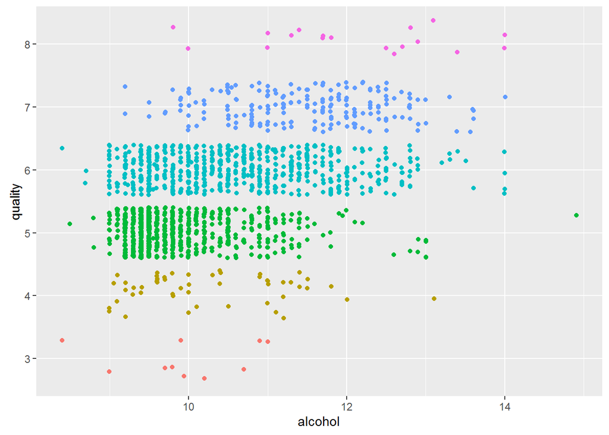

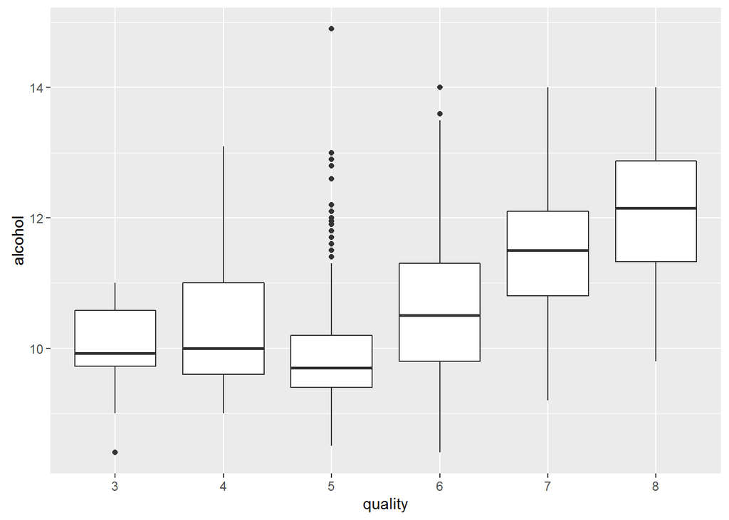

Based on the boxplot and the scatter plot, there seems to be a tentative positive relationship between alcohol and the quality of the wine (ie. wines with more alcohol tend to be better rated)

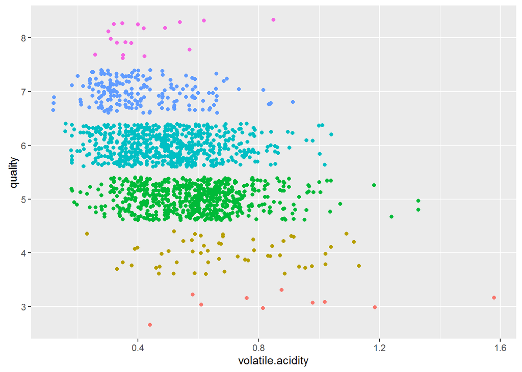

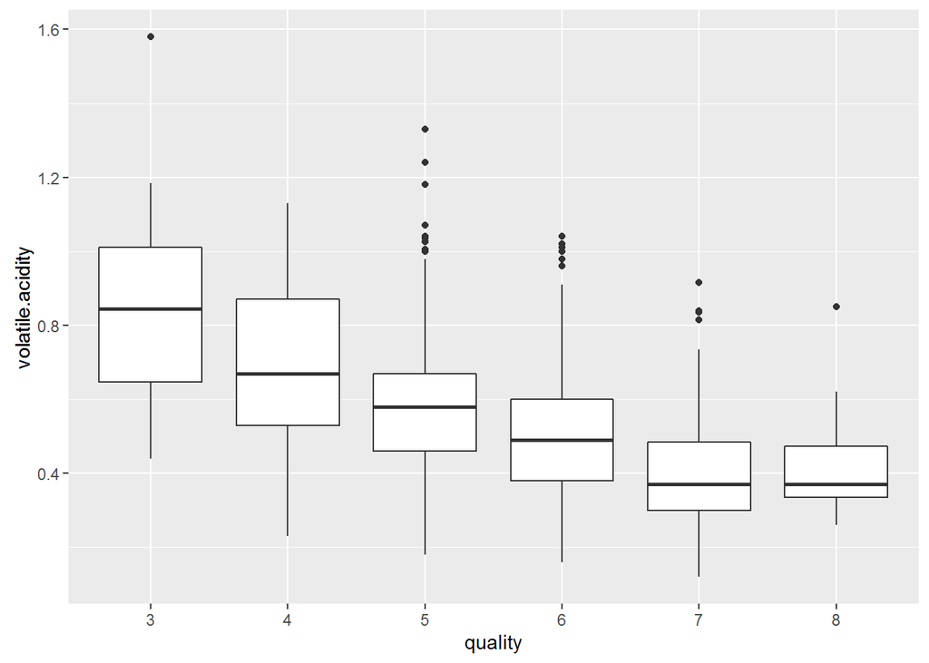

Based on the plots above, we can tell that there seems to be a negative relationship between the volatile acidity and the quality of the wine. The volatile acidity seems to get lower as the wine quality gets better.

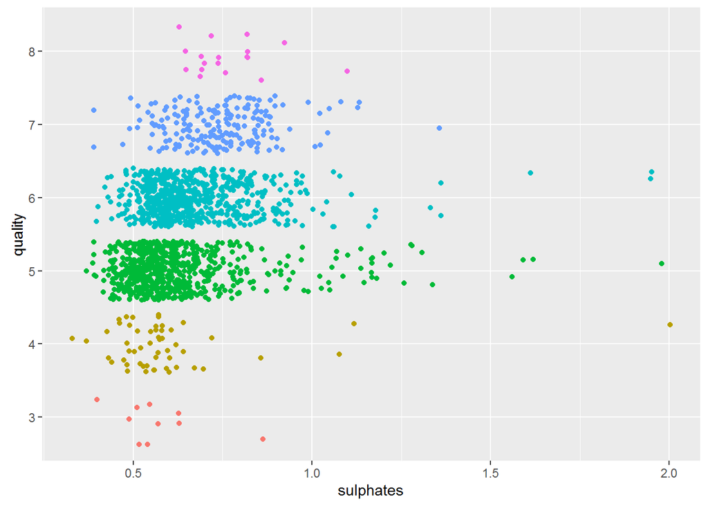

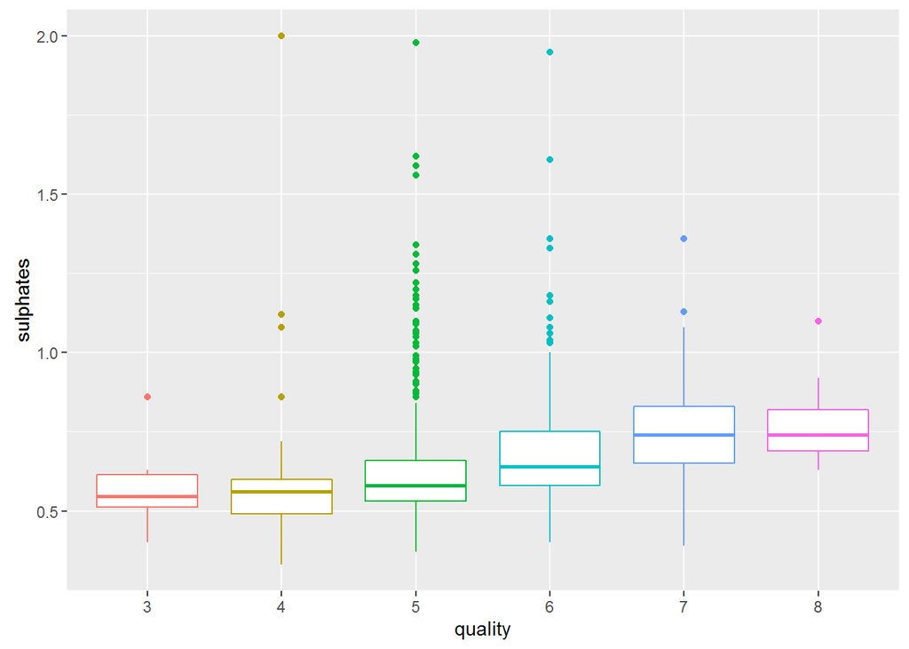

Based on the plots above, there seems to be a small positive relationship between the level of sulphates and the quality of the wine (ie the more the sulphates, better the quality of the wine). This is however, not a very pronounced relationship

# Bivariate Analysis

### Talk about some of the relationships you observed in this part of the investigation. How did the feature(s) of interest vary with other features in the dataset?

I explored 3 relationships as a part of my bivariate analysis:

1. Alchol - Quality : In the related plots, I found that there was a positive relationship between the two features and that wines with more alcohol tended to be better rated on the quality scale
2. Volatile Acidity - Quality: In my analysis, I found that there was a negative relationship between the two features and that wines with more volatile acidity(acetic acid) tended to be rated lower on the quality scale
3. Sulphates - Quality: In the related plots, I found that there was a small positive relationship between the level of sulphates and the quality of the wine. However this relationship wasn’t very clear and relatively minor compared to the relationships above

### Did you observe any interesting relationships between the other features (not the main feature(s) of interest)?

While I did not explore them in depth, the plot matrix did show some interesting strong relationships between: 1) citric acid and fixed acidity: strong positive correalation 2) citric acid and volatile acidity: strong negative correlation. This was interesting as it seems to suggest that the higher the citric acid, the lower the acetic acid (or volatile acidity) in the wine 3) density and fixed acidity: Positive correlation. The higher the fixed acidity, the denser the wine was found to be.

### What was the strongest relationship you found?

Related to the feature of interest, the alcohol-quality relationship was the strongest relationship.

# Multivariate Plots Section

In this section, I sought to analyze the relationships between the alcohol, volatile.acidity and sulphates features and looking at how they influence the quality of the wine.

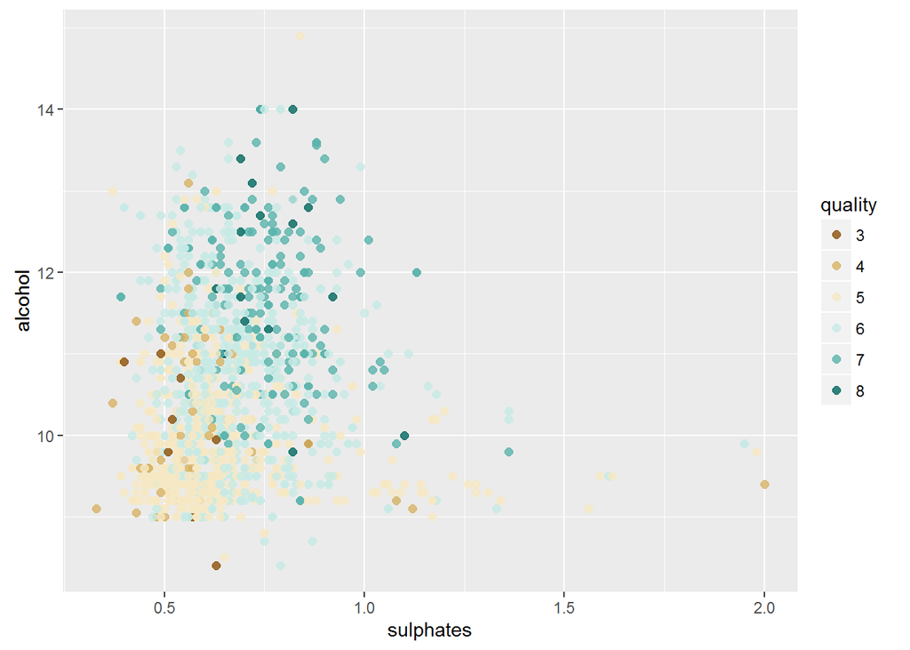

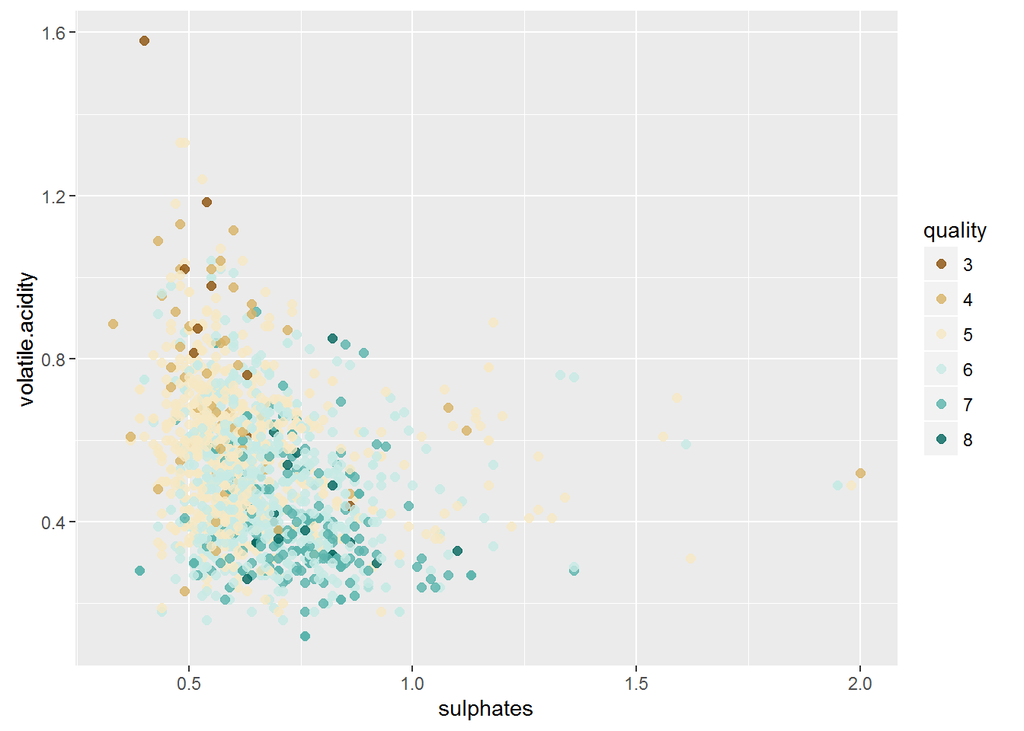

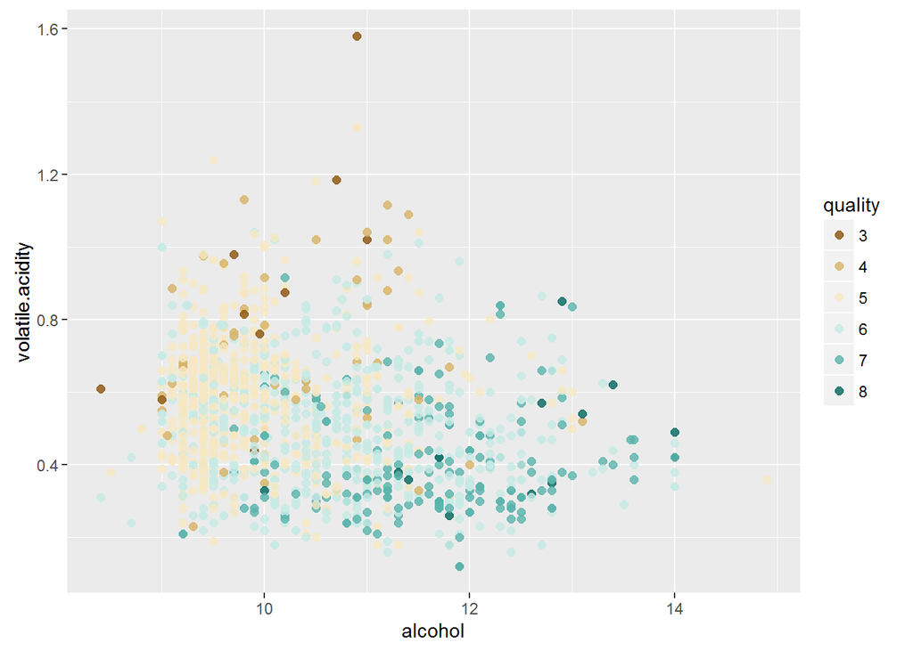

# Multivariate Analysis

### Talk about some of the relationships you observed in this part of the investigation. Were there features that strengthened each other in terms of looking at your feature(s) of interest?

Looking at the plots above, I noticed a few things:

Alcohol vs Volatile Acidity with colour = quality: I think this chart nicely culminates the effect as it shows that wines that are in the bottom right of the plot tend to to be better wines while wines in the top left (low alcohol, high volatile acidity) tend to be worse wines.

### Were there any interesting or surprising interactions between features?

It was interesting that volatile acidity had a slighlty negative relationship with both alcohol (-0.202) and sulphates(-0.261).

# Final Plots and Summary

### Plot One

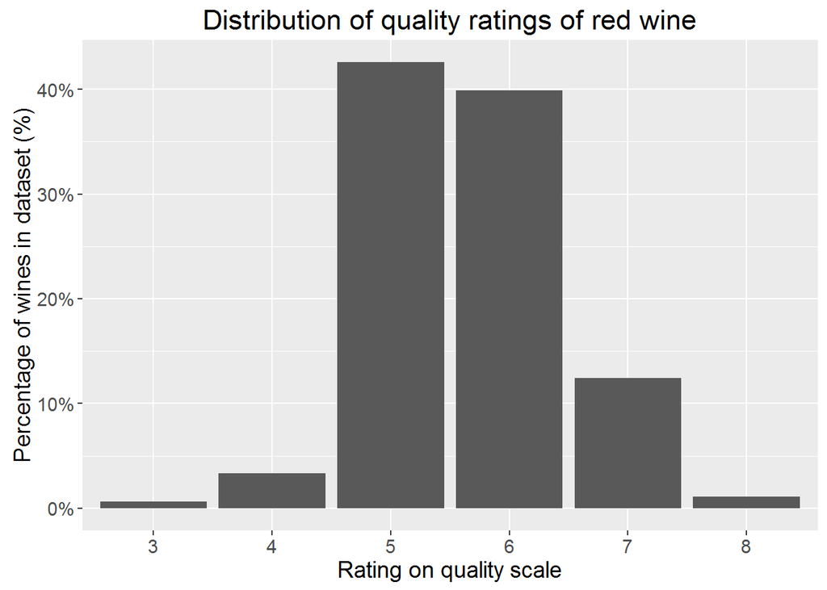

### Description One

Here we can see that a large percentage of the wines were ranked as a 5 or a 6 (over 80% to be more precise). Only less than 20% of the wines were ranked as good (7 or 8 ) or bad (3 or 4). No wines were ranked on the rest of the scale (1,2,9,10)

### Plot Two

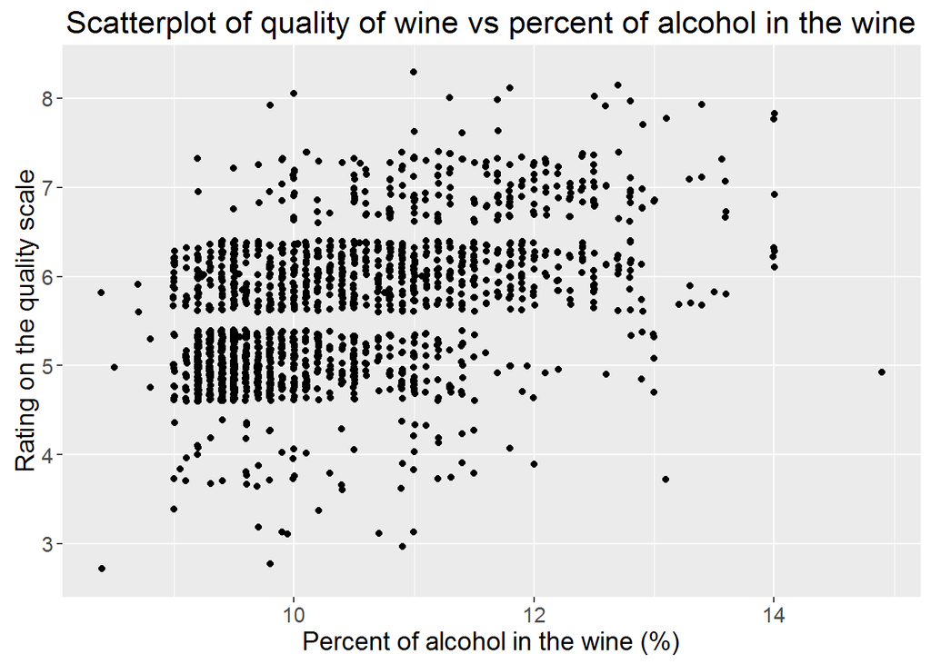

### Description Two

Based on the plot above we can see that wines with a greater percentage of alcohol in them tend to be better rated on the quality scale. For instance, most of the wines rated as 8 have an alcohol percentage of atleast 11% wheras all wines rated as 3 have an alcohol level below 11%. Also most wines with 14% alchol are rated atleast a 6 on the quality scale.

We can also see this from the fact that the correlation between the quality score and the percent of alchol is 0.476

### Plot Three

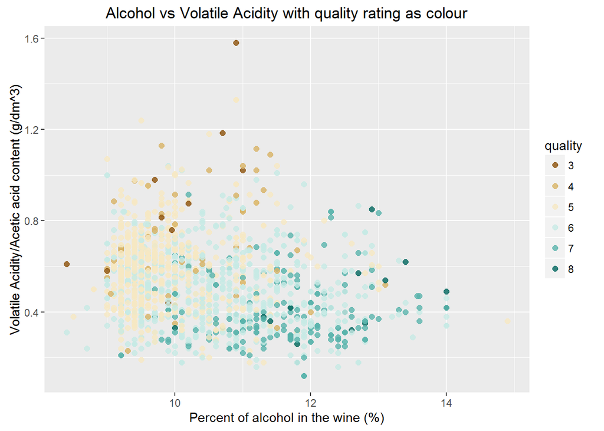

### Description Three

This plot shows that wines that are in the bottom right of the plot (high alcohol %, low volatile acidity) tend to to be better wines while wines in the top left (low alcohol, high volatile acidity) tend to be worse wines. All wines rated 3 have an alcohol content less than 11% while most of the wines rated 8 have an alchol content above 11%. With respect to volatile acidity, most wines rated 3 have a volatile acidity level above 0.6 g/dm^3 while wines rated 8 mostly have a volatile acidity level below 0.6 g/dm^3 ——

# Reflection

The goal of this analysis was to determine what chemical properties influenced the perceived quality of red wine. I started this analysis by looking at the distribution of all the individual features and then proceeded to look at the relationships that the features had with each other but also with the main feature of interest (quality). There was some moderate and strong correlations with quality (volatile acidity, alcohol, sulphates) and these became features that I explored further. Eventually I found that wines with more alcohol, less volatile acidity and to a small degree, more sulphates tended to be better wines on the quality scale. However it must be pointed out that none of these features had an extremely strong correlation with quality and that I did not use hypothesis testing to statistically test suggestions that I have made in my analysis (like wines tend to better when they have a higher alcohol content).

This could be one area to explore in the future. Also I think it may be useful to include wines outside the Portuguese “Vinho Verde” wine to check if these results are generalizable across all wines.

Furthermore, I would be very interested if the price of the wines and consumer ratings were added to the dataset as then we’d be able to explore several more interesting questions like: a) What sort of wines do consumers like? b) How does quality relate to price? c) How does price relate to the various chemical components?